# BIO539_Kopsco_FinalProject

Kopsco

5/8/2018

**INTRODUCTION**

Incidence of tick-borne disease has increased steadily across the United States in the past decade. Research suggests that there are approximately 300,000 new cases of Lyme disease each year, and although 95% of cases are reported from only 14 states, it is still the most common vector-borne disease in the country (CDC 2018). Health economists estimate that the current cost of Lyme disease to the U.S. healthcare system alone is between $712 million and $1.3 billion annually (Adrion et al. 2015). Reports of other tick-borne illnesses like babesiosis, ehrlichiosis, Rocky Mountain Spotted Fever, and various encephalitic viruses have doubled and tripled as their tick vector ranges expand (CDC 2018; Springer et al. 2015; Eisen et al. 2016). Aside from direct health care costs, the uptick in these illnesses is also having indirect mortalities such as a rise in babesia-infected blood bank reserves that have resulted in ~30% fatality rates in those transfusion patients who have received contaminated blood products (Lobo et al. 2013). The factors contributing to more cases of tick-borne diseases are complex and include broad ecological changes like changes in land use patterns, an increase in deer/wildlife populations overlaps with human-inhabited space, changes in human behavior that have resulted in enhanced exposure risks, and overall improvements in disease diagnosis, surveillance, and reporting (Beard & Strickman 2014).

Passive surveillance is a validated and widely employed tool to estimate and observe changes in tick abundances, disease prevalence, and habitat range (Rand et al. 2007, Xu et al. 2016, Koffi et al. 2017). Institutions using these surveillance programs are now beginning to examine these data to assess human behavior and epidemiologic factors related to tick encounters, for instance where embedded ticks are found on the body, and the age of the bite victim (Xu et al. 2016). However, passive systems that require ticks to be mailed to research centers are lacking in rapid-feedback education of the public regarding tick encounters. The TickSpotters program at the University of Rhode Island’s Center for Vector-borne Disease (CVB) is the longest-running online visual passive surveillance system in the country. It allows the public to submit photographs of ticks along with information surrounding the encounter, including the user identification of the tick. A response email is sent within 24 hours that identifies the tick to species and stage, andestimates feeding time, all time-critical information that can determine whether a person needs to take action to obtain prophylaxis medication. Based on the duration of feeding (estimated by the scutal index), we provide a detailed risk profile of low, moderate, or high risk of tick-specific disease transmission along with tick testing resources. Key preventative actions to prevent future encounters are also provided including instructions on how to perform a proper tick check, which tick repellent products are effective to use on people and pets, and in which specific habitats ticks can be found (e.g. trail edges). Here I present an analysis of two years of data from this surveillance system to establish predictor variables for tick literacy.

I used data collected from January 1st 2015 to December 31st, 2016 using Wufoo online forms program (SurveyMonkey, Inc.) to analyze and fit a model that predicts a person’s ability to correctly identify a tick. The online submission form provides TickSpotters users a tick identification chart and asks the user to identify the encountered tick to stage and species. Species options include ticks that are endemic to all regions of the United States and are specifically those that commonly feed on humans (versus wildlife). Identification options for species are blacklegged or deer tick (Ixodes scapularis), American dog tick (*Dermacentor variabilis*), Lone Star tick (*Amblyomma americanum*), Brown dog tick (*Rhipicephalus sanguineus*), Pacific Coast tick (*Dermacentor occidentalis*), western blacklegged tick (*Ixodes pacificus*), Rocky Mountain wood tick (*Dermacentor andersonii*), Gulf Coast tick (*Amblyomma maculatum*), and Cayenne tick (*Amblyomma cajennese*). The user was instructed to also identify the life stage (adult, nymph, or larva), enter the date the tick was found, on whom or what the tick found (on a person, pet, or loose), and state (or province in the case of Canada) of residence. For both species and stage there was an “unknown” option if the user could not choose the tick or the life stage. A photograph of the tick was attached to the submission and CVB staff reviewed entries on a daily basis. Tick photographs were examined by CVB staff and identified to species, stage, and feeding duration, and an email was sent to the participant with the correct identification and a risk assessment based on the tick/stage-specific diseases and prevalence of those diseases for the region of residence. Information was also provided in the email on how to prevent future tick bites and encounters on humans and pets by conducting regular tick checks, using permethrin repellent and tick knock-down pet products, and resources to submit ticks for testing should concern exist regarding infection.

**METHODS**

All basic descriptive analyses and model fitting were performed in R version 3.4.4/RStudio version 1.1.419. A logistic regression model was used as the deterministic function because of all of the variables analyzed were categorical, and the binomial distribution was used to model the probabilistic function because the correction variable for tick identification was binary (i.e. correction or no correction). The generalized linear model logit equation was used to test model parameters for the best predictors of tick literacy:

ln(odds) = ln(p/(1-p)) = a*x1 + b*x2 + … + z*xn

```
##     Northeast     Southeast       Midwest      Mountain     Southwest
##           447           244           215            20            36
##       Pacific Noncontiguous        Canada
##            82             1             0
```

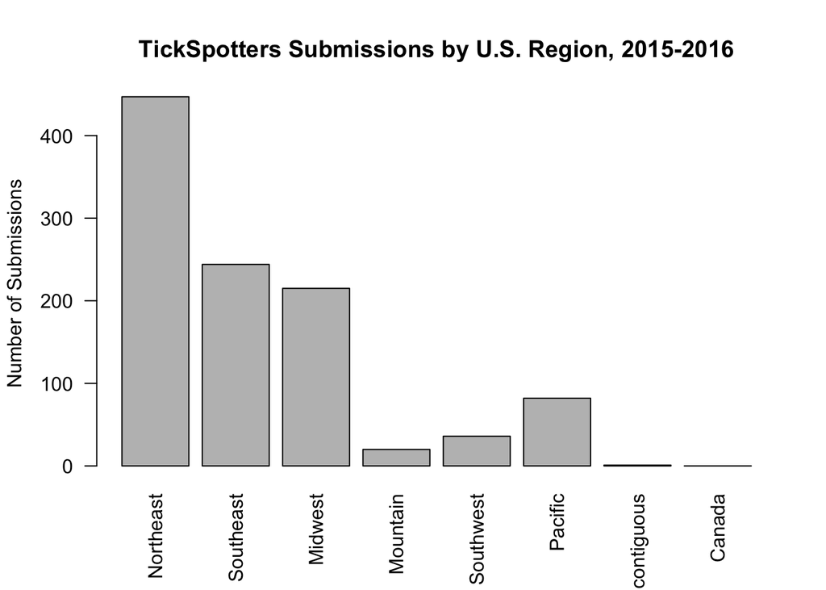

```
##   N   Y
## 705 340
```

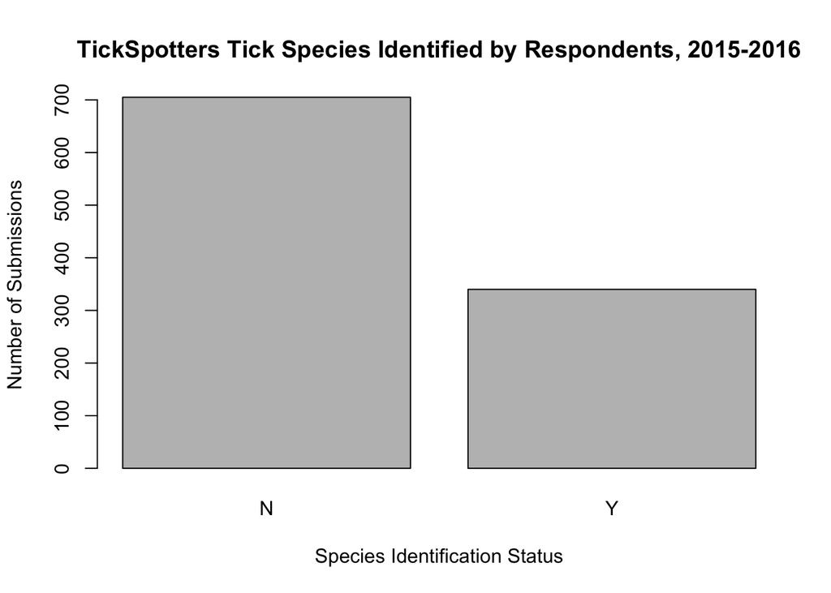

```
##       American Dog tick (Dermacentor variabilis)
##                                              342
##     Blacklegged or Deer tick (Ixodes scapularis)
##                                              344
##        Brown Dog tick (Rhipicephalus sanguineus)
##                                               25
##            Gulf Coast Tick (Amblyomma maculatum)
##                                               23
##            Lone Star tick (Amblyomma americanum)
##                                              183
##    Pacific Coast tick (Dermacentor occidentalis)
##                                               14
## Rocky Mountain Wood tick (Dermacentor andersoni)
##                                               22
##                                          Unknown
##                                               70
##      Western-Blacklegged tick (Ixodes pacificus)
##                                               22
```

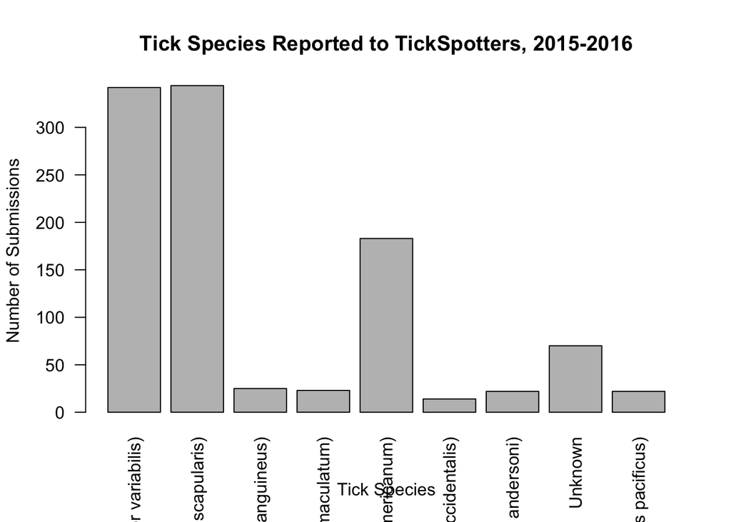

```
##   1  10  11  12   2   3   4   5   6   7   8   9
##  11  60  72  21  20  61 157 272 183 111  41  36
```

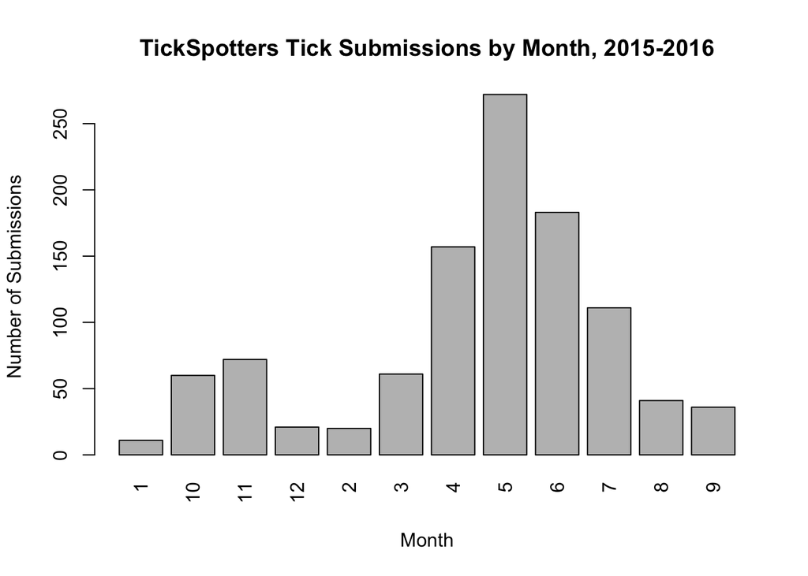

```
##   Adult   Larva   Nymph Unknown
##     809      13     153      70
```

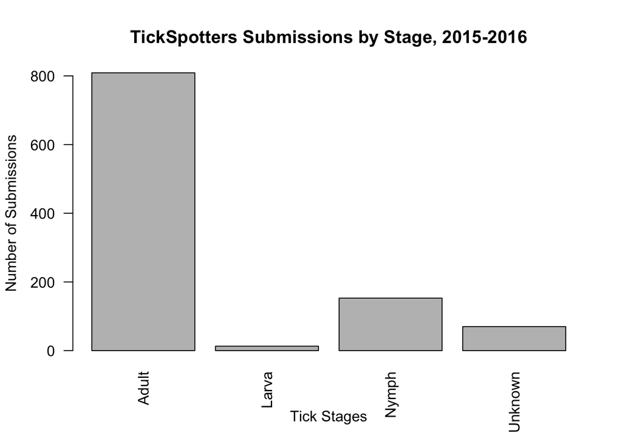

```
##  Female   Larva    Male   Nymph Unknown
##     581      13     226     155      70
```

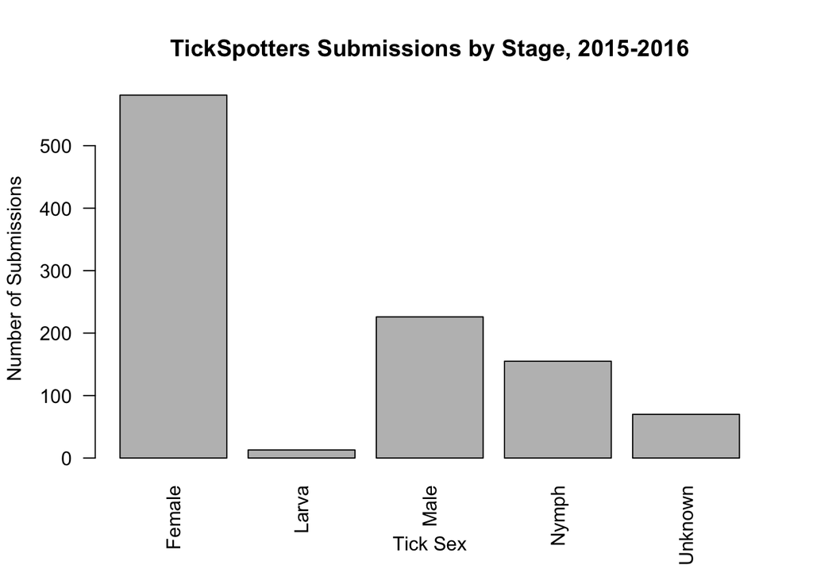

```
## Loose and wandering         On a person            On a pet
##                  64                 748                 233
```

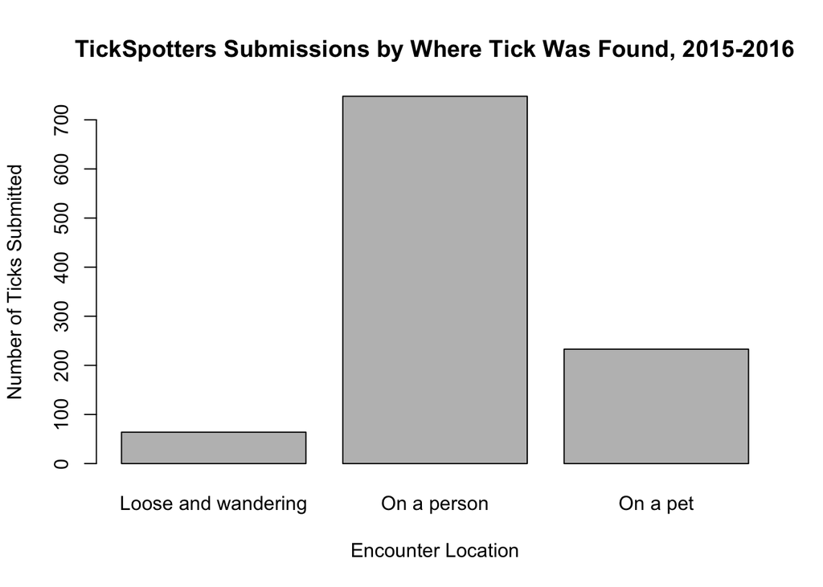

```
##       0       1     1.5       2     2.5       3     3.5       4     4.5
##     496     159      49      68      20      74      37      57       8
##       5       6       7       8 Unknown
##      44      11      14       2       6
```

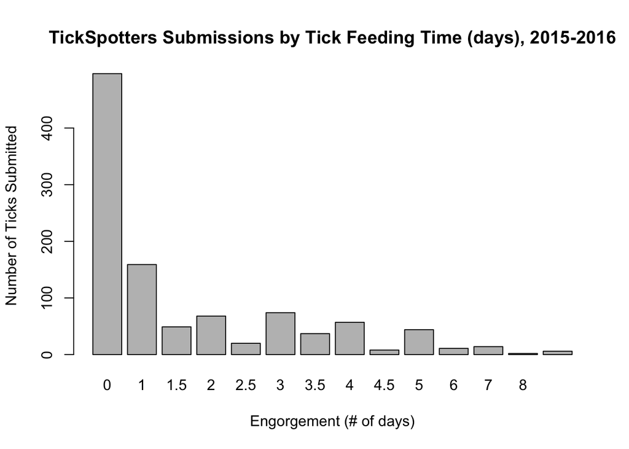

RESULTS

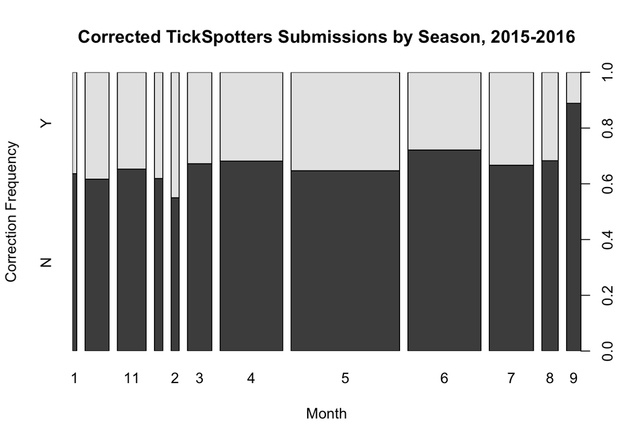

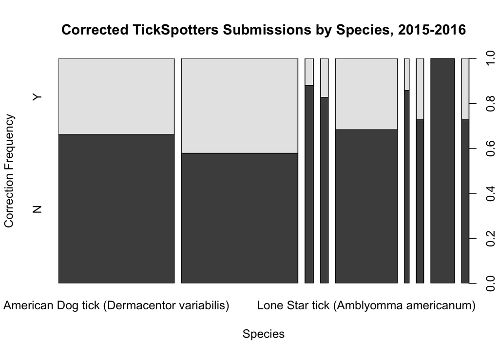

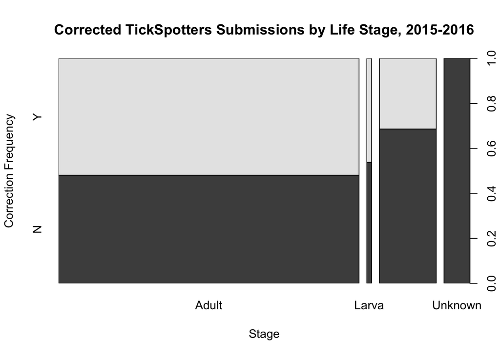

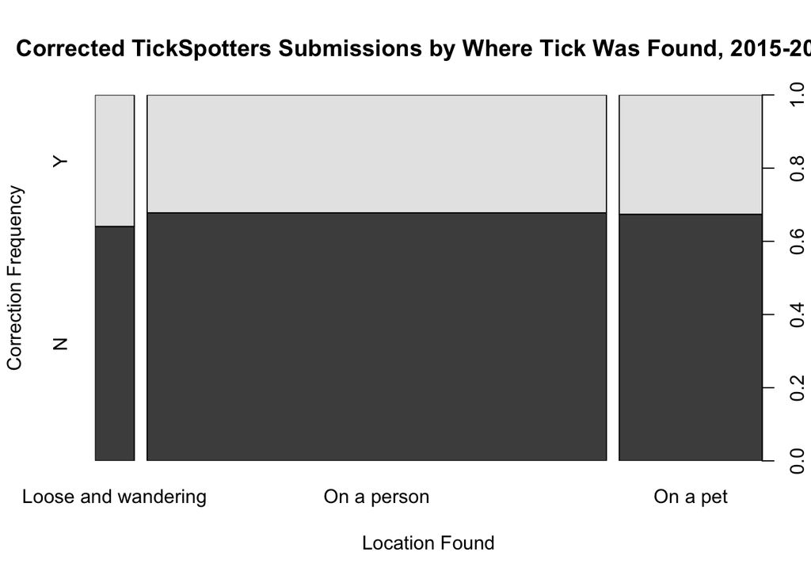

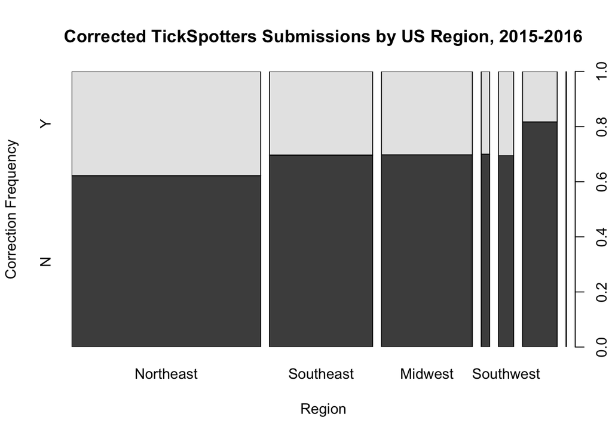

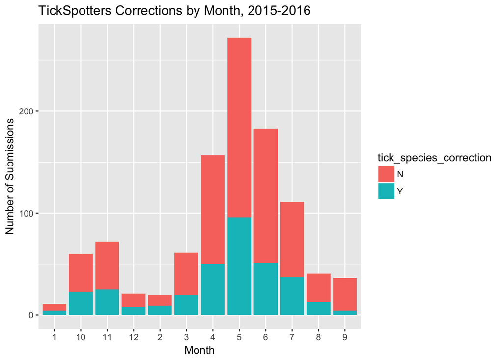

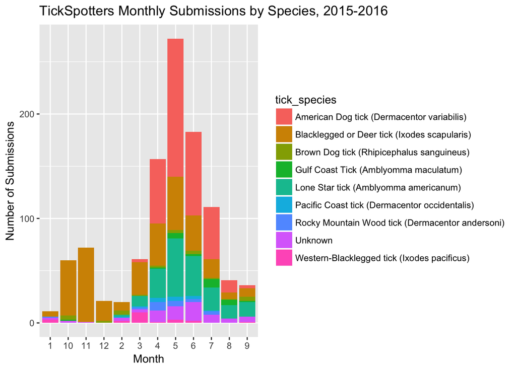

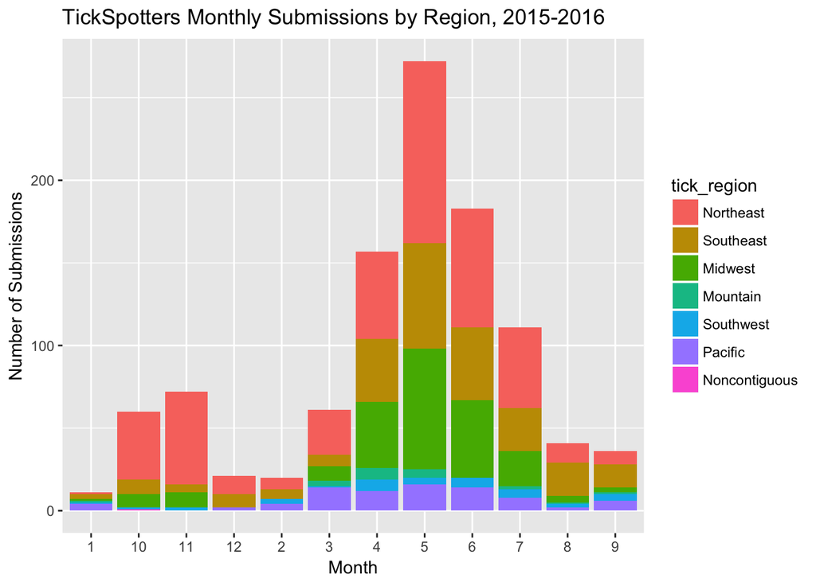

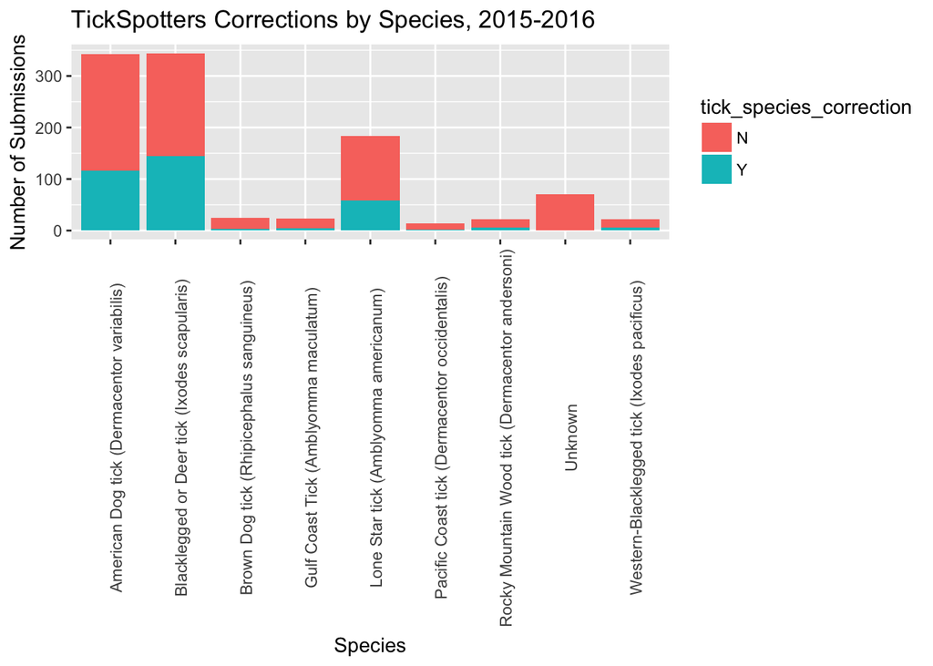

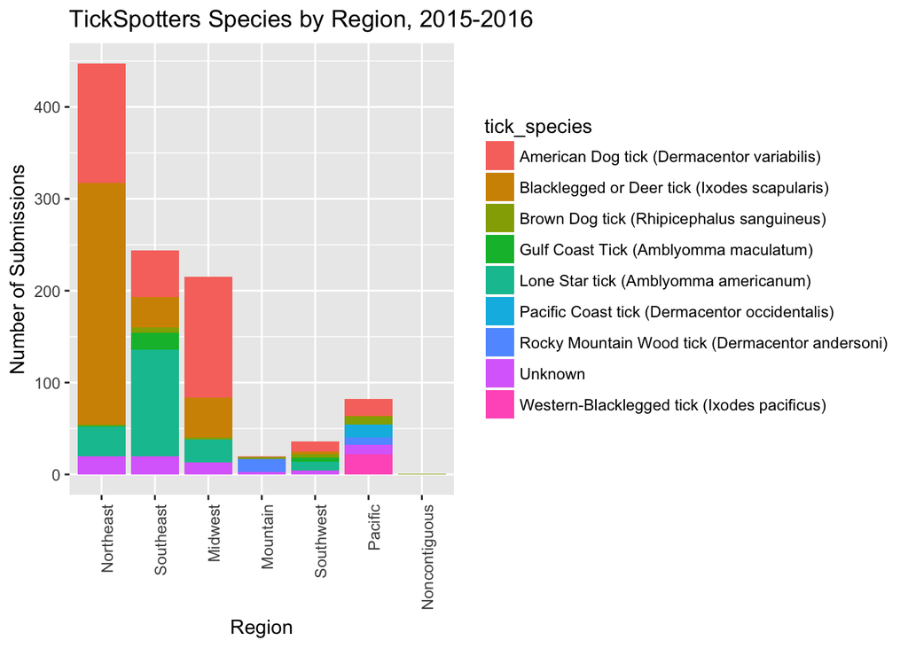

**DISCUSSION**

Additional analysis is required to assess whether additional predictors and/or interactions among predictors will create a more robust model. Once the best model for the data has been established by AIC/BIC, cross-validation and to estimate how well the models fit the test set of the data. Finally, a receiver operator characteristic (ROC) curve should be performed to assess the model’s sensitivity and accuracy on the test dataset.

**REFERENCES**

Adrion ER, Aucott J, Lemke KW, and Weiner JP. 2015. Health Care Costs, Utilization and Patterns of Care following Lyme Disease. PLoS One. 10(2): e0116767.

Beard CB and Strickman D. 2014. Federal Initiative: Tick-Borne Disease Integrated Pest Management White Paper. Accessed November 2016: https://www.epa.gov/pesp/federal-initiative-tick-borne-disease-integrated-pest-management-white-paper

CDC. 2018. Data and statistics. Atlanta, GA: US Department of Health and Human Services, CDC. Available at http://www.cdc.gov/lyme/stats/index.html.

Eisen RJ, Eisen L, Beard CB. 2016. County-Scale Distribution of Ixodes scapularis and Ixodes pacificus (Acari: Ixodidae) in the Continental United States. Journal of Medical Entomology. 0:1-38.

Koffi JK, Savage K, Thivierge K, Lindsay RL, Bouchard C, Pelcat Y, and Ogden NH. 2017. Evaluating the submission of digital images as a method of surveillance for Ixodes scapularis ticks. Parasitology. 144: 877-883.

Lobo L, Cursino-Santos JR, Alhassan A, and Rodrigues M. 2013. Babesia: An Emerging Infectious Threat in Transfusion Medicine. PLoS Pathogens. 9(7): e1003387.

Rand PW, Lacombe EH, Dearborn R, Cahill R, Elias S, Lubeczyk CB, Beckett GA, Smith RP. 2007. Journal of Medical Entomology. 44(6): 1118-1129.

Springer YP, Eisen L, Beat L, James AM, and Eisen R. 2014. Spatial Distribution of Counties in the Continental United States with Records of Occurrence of Amblyomma americanum (Ixodida: Ixodidae). Journal of Medical Entomology. 51(2): 342-351.

Xu G, Mather TN, Hollingsworth CS, Rich SM. 2016. Passive Surveillance of Ixodes scapularis (Say), Their Biting Activity, and Associated Pathogens in Massachusetts. Vector-borne and Zoonotic Diseases. 16(8): 520-527.